# Intro to Machine Learning; Linear Regression Models

```python
import pandas as pd

import numpy as np
```

## Music Challenge

Which popular songs from the past will be recognized by future generations, and which will fade into obscurity? The website [The Pudding](https://pudding.cool/) conducts the [Music Challenge](https://pudding.cool/2020/04/music-challenge/) where they ask thousands of people whether they recognize hit songs from the past. We’ll look at some of the data related to the article [“Defining the 90s Music Canon”](https://pudding.cool/2020/07/song-decay/).

The data set at https://raw.githubusercontent.com/the-pudding/song-decay-clean/refs/heads/master/src/assets/data/lollipop_chart_data_july_13.csv contains 344 songs released in the 1990s. For each song, the proportion of survey respondents who recognized the song is recorded, for both Millennial respondents and Gen Z respondents. Our goal will be to use linear regression to **predict the Gen Z recognition**.

We will try several different linear regression models. Save each of your models with a different name because you will compare them at the end.

0. Read in the data and describe the Gen Z recognition variable.

```python
songs = pd.read_csv(
    "https://raw.githubusercontent.com/the-pudding/song-decay-clean/refs/heads/master/src/assets/data/lollipop_chart_data_july_13.csv"
)

songs = songs.rename(
    columns={
        "mean_millennial_recognition": "millennial",
        "mean_gen_z_recognition": "gen_z"
    }
)

songs["gen_z"].describe()
```

```
count    344.000000
mean       0.235506
std        0.210541
min        0.019483
25%        0.095589
50%        0.155398
75%        0.303051
max        0.963497
Name: gen_z, dtype: float64
```

1. Use scikit-learn to fit a linear regression model for predicting Gen Z recognition from Millennial recognition.

```python
from sklearn.linear_model import LinearRegression

X = songs[["millennial"]]
y = songs["gen_z"]

linear_model = LinearRegression()
linear_model.fit(X, y)

print("intercept:", linear_model.intercept_)
print("slope:", linear_model.coef_)
print("R²:", linear_model.score(X, y))
```

```
intercept: -0.04814972198183051
slope: [0.70673118]
R²: 0.7969941647566873
```

2. Make a scatterplot of Gen Z recognition versus Millennial recognition, and overlay a graph of the fitted model from the previous part.

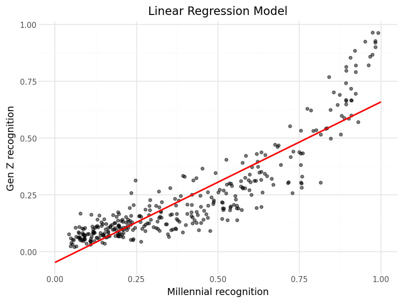

```python
from plotnine import ggplot, aes, geom_point, geom_line, labs, theme_minimal

grid = pd.DataFrame({
    "millennial": np.linspace(0, 1, 101)
})

grid["prediction"] = linear_model.predict(grid[["millennial"]])

(
    ggplot(songs, aes(x="millennial", y="gen_z"))
    + geom_point(alpha=0.5)
    + geom_line(
        grid,
        aes(x="millennial", y="prediction"),
        color="red",
        size=1
    )
    + labs(
        x="Millennial recognition",
        y="Gen Z recognition",
        title="Linear Regression Model"
    )
    + theme_minimal()
)
```

3. Explain why you might want to consider taking a log of Gen Z recognition. Then use scikit-learn to fit a linear regression model for predicting log of Gen Z recognition from Millennial recognition.

```python
# Gen Z recognition is right-skewed and cannot be below 0.
# Taking a log can make the curved relationship more linear.

y_log = np.log(songs["gen_z"])

log_model = LinearRegression()
log_model.fit(X, y_log)

print("intercept:", log_model.intercept_)
print("slope:", log_model.coef_)
print("R² (log scale):", log_model.score(X, y_log))
```

```
intercept: -2.9082912239452847
slope: [2.79916804]
R² (log scale): 0.8230294902084204
```

4. Make a scatterplot of Gen Z recognition versus Millennial recognition, and overlay a graph of the fitted model from the previous part.

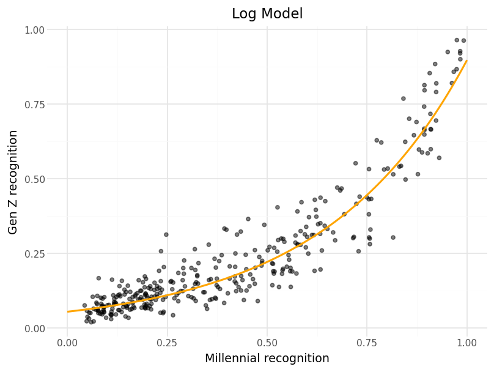

```python
grid["log_prediction"] = np.exp(
    log_model.predict(grid[["millennial"]])
)

(
    ggplot(songs, aes(x="millennial", y="gen_z"))
    + geom_point(alpha=0.5)
    + geom_line(
        grid,
        aes(x="millennial", y="log_prediction"),
        color="orange",
        size=1
    )
    + labs(
        x="Millennial recognition",
        y="Gen Z recognition",
        title="Log Model"
    )
    + theme_minimal()
)
```

5. Now we’ll try a polynomial model for predicting Gen Z recognition from Millennial recognition. Use scikit-learn to fit a model with two features: Millennial recognition and its square.

```python
songs["millennial_sq"] = songs["millennial"] ** 2

X_sq = songs[["millennial", "millennial_sq"]]

square_model = LinearRegression()
square_model.fit(X_sq, y)

print("R²:", square_model.score(X_sq, y))
```

```
R²: 0.8975034473753132
```

```python
square_model.coef_, square_model.intercept_
```

```
(array([-0.27263527,  1.02072241]), np.float64(0.10851294576257658))
```

6. Make a scatterplot of Gen Z recognition versus Millennial recognition, and overlay a graph of the fitted model.

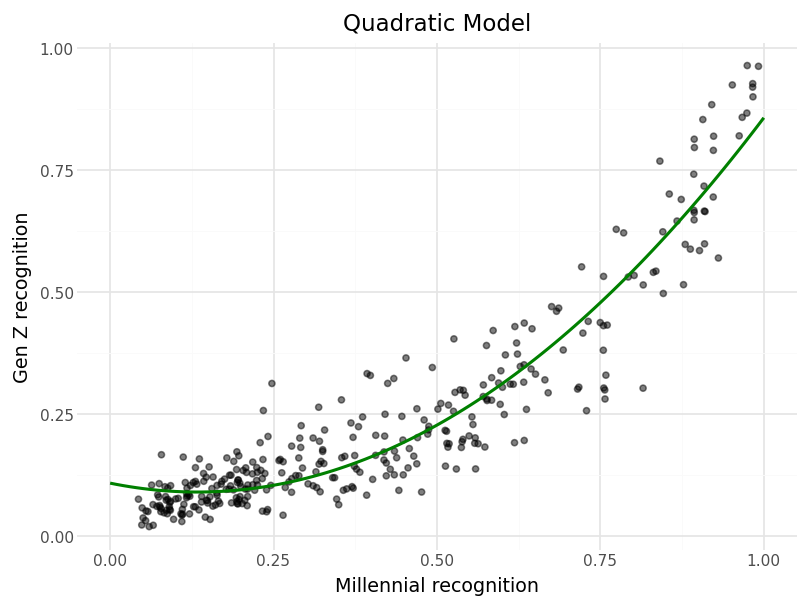

```python
grid["millennial_sq"] = grid["millennial"] ** 2

grid["square_prediction"] = square_model.predict(
    grid[["millennial", "millennial_sq"]]
)

(
    ggplot(songs, aes(x="millennial", y="gen_z"))
    + geom_point(alpha=0.5)
    + geom_line(
        grid,
        aes(x="millennial", y="square_prediction"),
        color="green",
        size=1
    )
    + labs(
        x="Millennial recognition",
        y="Gen Z recognition",
        title="Quadratic Model"
    )
    + theme_minimal()
)
```

7. Choose one of your favorite songs that is in the data set. Use each model to predict the Gen Z recognition for the song. Which model gives the best prediction?

```python
song = songs[
    songs["artist_song"].str.contains("Waterfalls", case=False, na=False)
]

song
```

|  | artist_song | millennial | gen_z | millennial_sq |
| --- | --- | --- | --- | --- |
| 301 | TLC\|\|\|Waterfalls | 0.846265 | 0.496892 | 0.716165 |

```python
m = song["millennial"].iloc[0]
actual = song["gen_z"].iloc[0]

new_song = pd.DataFrame({
    "millennial": [m],
    "millennial_sq": [m ** 2]
})

linear_prediction = linear_model.predict(
    new_song[["millennial"]]
)[0]

log_prediction = np.exp(
    log_model.predict(new_song[["millennial"]])
)[0]

square_prediction = square_model.predict(
    new_song[["millennial", "millennial_sq"]]
)[0]

print("Actual Gen Z recognition:", actual)
print("Linear prediction:", linear_prediction)
print("Log prediction:", log_prediction)
print("Quadratic prediction:", square_prediction)
```

```
Actual Gen Z recognition: 0.496891996891997
Linear prediction: 0.5499323973895877
Log prediction: 0.5830675318468128
Quadratic prediction: 0.6087968943109525
```

8. The song “Smells Like Teen Spirit” by Nirvana is inexplicably not included in the data set. Suppose the Millenial recognition of this song is 0.7. Use each model to predict the Gen Z recognition for this song. Which model gives the best prediction?

```python
new_song = pd.DataFrame({
    "millennial": [0.7],
    "millennial_sq": [0.7 ** 2]
})

print(
    "Linear:",
    linear_model.predict(new_song[["millennial"]])[0]
)

print(
    "Log:",
    np.exp(log_model.predict(new_song[["millennial"]]))[0]
)

print(
    "Quadratic:",
    square_model.predict(
        new_song[["millennial", "millennial_sq"]]
    )[0]
)
```

```
Linear: 0.44656210353892223
Log: 0.3871768945256204
Quadratic: 0.41782223812893693
```

## Categorical Predictors (FEV data)

Do non-smokers have better lungs than smokers? One measure of lung function is forced expiratory volume (FEV), the amount of air (in liters) an individual can exhale in the first second of forceful breath. Larger values of FEV are indicative of better functioning lungs. In a study, FEV was measured for a group of 654 subjects, along with whether or not they smoked and other variables.

```python
df_fev = pd.read_csv("https://raw.githubusercontent.com/kevindavisross/data301/refs/heads/main/data/FEV.csv")

df_fev
```

|  | ID | Smoking status | FEV | Height | Age (months) |
| --- | --- | --- | --- | --- | --- |
| 0 | 201 | non-smoker | 2.884 | 69.0 | 132 |
| 1 | 202 | non-smoker | 2.328 | 64.0 | 120 |
| 2 | 301 | non-smoker | 1.708 | 57.0 | 108 |
| 3 | 341 | non-smoker | 3.381 | 63.0 | 172 |
| 4 | 351 | non-smoker | 2.170 | 58.0 | 130 |
| ... | ... | ... | ... | ... | ... |
| 649 | 83841 | non-smoker | 2.115 | 50.0 | 58 |
| 650 | 83901 | non-smoker | 2.328 | 60.0 | 98 |
| 651 | 83951 | smoker | 3.069 | 65.0 | 130 |
| 652 | 83952 | non-smoker | 1.495 | 57.0 | 85 |
| 653 | 90001 | non-smoker | 2.785 | 69.0 | 131 |

654 rows × 5 columns

1. First fit a regression model with a single predictor: Smoking status. Since this variable is categorical you need to “dummify” it before fitting the model.

```python
df_fev = df_fev.rename(
    columns={
        "Smoking status": "smoking",
        "Age (months)": "age_months"
    }
)

df_fev["smoker"] = (
    df_fev["smoking"] == "smoker"
).astype(int)

smoke_model = LinearRegression()
smoke_model.fit(df_fev[["smoker"]], df_fev["FEV"])

print("intercept:", smoke_model.intercept_)
print("smoker coefficient:", smoke_model.coef_)
print("R²:", smoke_model.score(df_fev[["smoker"]], df_fev["FEV"]))
```

```
intercept: 2.566142614601019
smoker coefficient: [0.71071892]
R²: 0.06023322003569476
```

2. What are the predictions from this model? How could we have known that those would be the predictions?

```python
two_groups = pd.DataFrame({
    "smoker": [0, 1]
})

two_groups["predicted_FEV"] = smoke_model.predict(
    two_groups[["smoker"]]
)

print(two_groups)

df_fev.groupby("smoking")["FEV"].mean()
```

```
   smoker  predicted_FEV
0       0       2.566143
1       1       3.276862
```

```
smoking
non-smoker    2.566143
smoker        3.276862
Name: FEV, dtype: float64
```

3. Look at the results for the previous parts. What do you notice? Is this what you expected? Remember: larger FEV means better lungs - who tends to have larger FEV, smokers or non-smokers?

Smokers have a higher average FEV than non-smokers in this dataset. This is unexpected because higher FEV means better lung function. However, the model has a low R², so smoking status alone explains very little of the difference in FEV.

4. Suggest some explanations for why smokers tend to have *higher* FEV than non-smokers?

Age is likely affecting the result. Smokers in this dataset are generally older, and older children and teenagers tend to have larger lungs and higher FEV. Height or body size could also matter. This shows an association, not proof that smoking improves lung function.

5. Fit a linear regression model with two predictors: smoking status and Age (and no interaction).

```python
X_sa = df_fev[["smoker", "age_months"]]

smoke_age_model = LinearRegression()
smoke_age_model.fit(X_sa, df_fev["FEV"])

print("intercept:", smoke_age_model.intercept_)
print(
    pd.Series(
        smoke_age_model.coef_,
        index=X_sa.columns
    )
)
print("R²:", smoke_age_model.score(X_sa, df_fev["FEV"]))
```

```
intercept: 0.36814675002691644
smoker       -0.217178
age_months    0.019212
dtype: float64
R²: 0.575903467141671
```

6. Make a scatterplot of FEV versus Age, colored by smoking status, and overlay a graph of the fitted model.

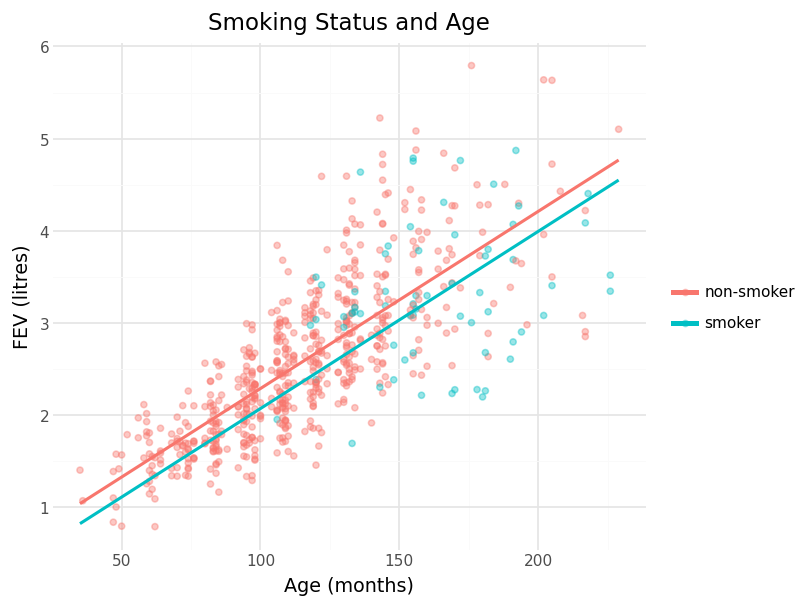

```python
ages = np.linspace(
    df_fev["age_months"].min(),
    df_fev["age_months"].max(),
    50
)

grid_fev = pd.DataFrame({
    "age_months": np.tile(ages, 2),
    "smoker": np.repeat([0, 1], 50)
})

grid_fev["smoking"] = np.where(
    grid_fev["smoker"] == 1,
    "smoker",
    "non-smoker"
)

grid_fev["prediction"] = smoke_age_model.predict(
    grid_fev[["smoker", "age_months"]]
)

(
    ggplot(df_fev, aes(x="age_months", y="FEV", color="smoking"))
    + geom_point(alpha=0.4)
    + geom_line(grid_fev, aes(y="prediction"), size=1)
    + labs(
        x="Age (months)",
        y="FEV (litres)",
        color="",
        title="Smoking Status and Age"
    )
    + theme_minimal()
)
```

7. Fit a linear regression model with predictors smoking status, Age, and their interaction.

```python
df_fev["smoker_x_age"] = (
    df_fev["smoker"] * df_fev["age_months"]
)

X_int = df_fev[
    ["smoker", "age_months", "smoker_x_age"]
]

interaction_model = LinearRegression()
interaction_model.fit(X_int, df_fev["FEV"])

print("intercept:", interaction_model.intercept_)
print(
    pd.Series(
        interaction_model.coef_,
        index=X_int.columns
    )
)
print(
    "R²:",
    interaction_model.score(X_int, df_fev["FEV"])
)
```

```
intercept: 0.25946202327124324
smoker          1.870057
age_months      0.020162
smoker_x_age   -0.013110
dtype: float64
R²: 0.5920428464352646
```

8. Make a scatterplot of FEV versus Age, colored by smoking status, and overlay a graph of the fitted model.

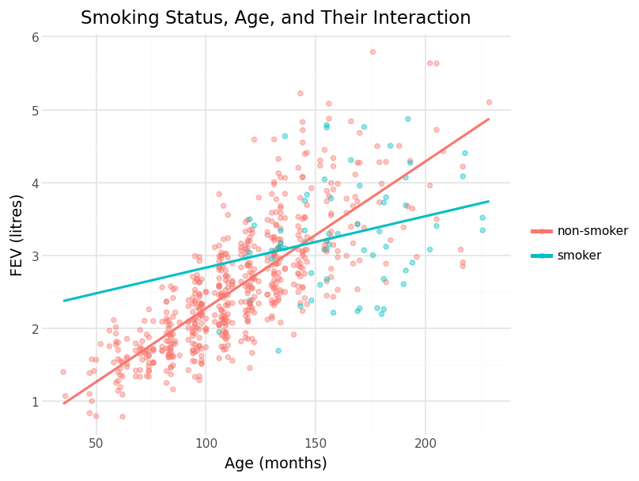

```python
grid_fev["smoker_x_age"] = (
    grid_fev["smoker"] * grid_fev["age_months"]
)

grid_fev["interaction_prediction"] = interaction_model.predict(
    grid_fev[
        ["smoker", "age_months", "smoker_x_age"]
    ]
)

(
    ggplot(df_fev, aes(x="age_months", y="FEV", color="smoking"))
    + geom_point(alpha=0.4)
    + geom_line(
        grid_fev,
        aes(y="interaction_prediction"),
        size=1
    )
    + labs(
        x="Age (months)",
        y="FEV (litres)",
        color="",
        title="Smoking Status, Age, and Their Interaction"
    )
    + theme_minimal()
)
```

9. Compare the models. Which do you think is “best”? Why? How could you investigate?

The interaction model seems best as it has the highest R^2 and allows smoking status to change the relationship between age and FEV. However, fitted R^2 goes up when extra predictors are added. To properly compare the models, use a train/test split or cross-validation and compare their test RMSE values.